# Data visualisations on parks in the USA

2022-10-24

```r
parks <- read_csv("../data/parks.csv")
# or alternatively, if the file cannot be loaded use
# parks <- readr::read_csv('https://raw.githubusercontent.com/rfordatascience/tidytuesday/master/data/2021/2021-06-22/parks.csv')
```

# Introduction

Since the pandemic, it is observed that more people come to the park. It is a safe place to look for fresh air and change scenery since most people are bored with their house due to restrctions. We will be taking a look at `parks.csv` file from [TidyTuesday](https://github.com/rfordatascience/tidytuesday/blob/master/data/2021/2021-06-22/readme.md). It contains data about parks from cities in USA.

A brief description of variables (columns) in the dataset:

1. **year**: year the park measured
2. **rank**: rank of the park according to **total_points** received counted yearly.
3. **city**: name of city
4. **med_park_size**: median park size
5. **park_pct_city**: percentage of city area used as park
6. **pct_near_park**: percentage of resident living near the park (approx. 10 mins)
7. **spend_per_resident**: spending per resident in that city
8. **amenities_points**: total points of amenities around the park. It is the sum of:
   - **basketball_points**,
   - **dogpark_points**,
   - **playground_points**,
   - **rec_sr_points**,
   - **restroom_points**, and
   - **splashground_points**
9. **total_points**: the total points the park get.

The focus of this project is the improvement of park in USA. Due to the increasing demand of park usage, it is important to keep the park maintained and improved every year.

The first step is to clean the data since a column on the year 2017 is put wrongly. Next, interpolate missing data of total_points column by summing up the points data we have. Lastly, standardise the data format of columns not in standard form.

```r
parks %>% filter(year == 2017) %>%
  mutate(total_pct = total_points) -> parks_2017

parks %>% filter(year != 2017) -> parks_other

parks <- bind_rows(parks_2017, parks_other) %>%
  filter(year > 2014) %>%
  arrange(desc(year), rank) %>%
  rowwise() %>%
  mutate(total_points = floor(sum(c_across(cols = c(med_park_size_points,
                                                    park_pct_city_points,
                                                    pct_near_park_points,
                                                    spend_per_resident_points,
                                                    amenities_points))) + 0.5),
         across(contains("pct") | "spend_per_resident_data",
                .fns = ~as.numeric(str_extract(.x, "\\d+")))) %>%
  ungroup() %>% group_by(year) %>%
  mutate(rank = rank(rank, ties.method = "first")) %>%
  ungroup()
```

# Plot 1

The first plot focuses more on **total_points** of each city’s park to see how well the park is from the year 2015 to 2020. Each color represents a different city.

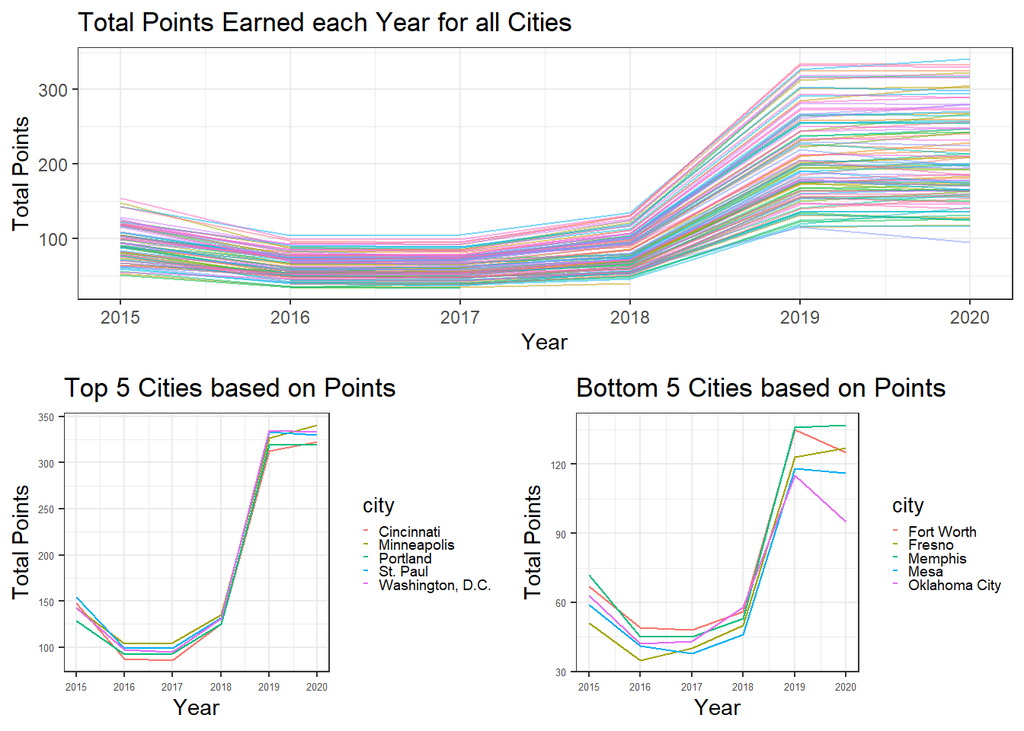

```r
parks %>%
  group_by(city) %>%
  mutate(total = sum(total_points, na.rm = TRUE)) %>%
  ungroup() %>% arrange(desc(total)) %>%
  slice(1:30) %>%
  ggplot(aes(x = year, y = total_points, color = city)) +
  geom_line() +
  labs(title = "Top 5 Cities based on Points", x = "Year", y = "Total Points") +
  theme_bw() +
  theme(legend.key.size = unit(1, units = "mm"),
        legend.key.height = unit(1, units = "mm"),
        legend.key.width = unit(1, units = "mm"),
        legend.text = element_text(size = 7),
        legend.title = element_text(size = 10),
        axis.text.x = element_text(size = 5),
        axis.text.y = element_text(size = 5)) -> top_5_parks_plot

parks %>%
  group_by(city) %>%
  mutate(total = sum(total_points), count_year = n()) %>%
  ungroup() %>%
  arrange(desc(count_year), total) %>%
  slice(1:30) %>%
  ggplot(aes(x = year, y = total_points, color = city)) +
  geom_line() +
  labs(title = "Bottom 5 Cities based on Points", x = "Year", y = "Total Points") +
  theme_bw() +
  theme(legend.key.size = unit(1, units = "mm"),
        legend.key.height = unit(1, units = "mm"),
        legend.key.width = unit(1, units = "mm"),
        legend.text = element_text(size = 7),
        legend.title = element_text(size = 10),
        axis.text.x = element_text(size = 5),
        axis.text.y = element_text(size = 5)) -> bot_5_parks_plot

parks %>%
  ggplot(aes(x = year, y = total_points, color = city)) +
  geom_line(alpha = 0.5) +
  labs(title = "Total Points Earned each Year for all Cities", x = "Year", y = "Total Points") +
  theme_bw() +
  theme(legend.position = "none") -> all_cities_plot

ggarrange(all_cities_plot,
          ggarrange(top_5_parks_plot,
                    bot_5_parks_plot,
                    ncol = 2),
          nrow = 2)
```

It can be seen that the **total_points** increase drastically. To see the trend better, two graphs representing the ‘best’ park and ‘worst’ park respectively has been given. 2019 and 2020 are the years of pandemic so there might be a corellation between those two. A choice of parallel coordinate plot is made to emphasize the difference in **total_points**. It is also grouped by cities to see if the trend can be applied to all parks instead of just a few ensuring no development gap between cities. If the development gap exists, without grouping by cities, the **total_points** may still improve, but only because a few parks is catered way more than the other.

The opacity of all cities graph is set to `0.5` to easily see all the lines. The `theme` is changed to bw to make the line stand out more than the background. Additional two graphs for the top and bottom parks are there to give a better understanding of what it looks like for the park cared the most and the least. The interesting part is to see that even the ‘worst’ park is still developed well altough might not be maintained too well since some of them drops on the year 2020.

# Plot 2

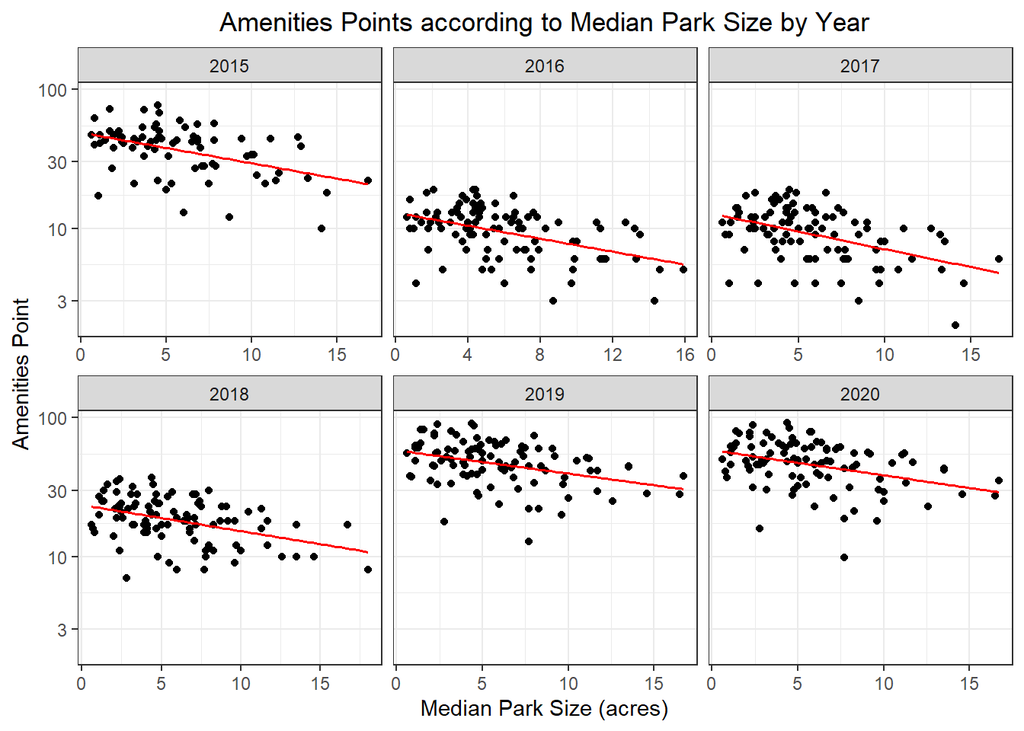

```r
parks %>%
  ggplot(aes(x = med_park_size_data, y = amenities_points)) +
  geom_point() +
  geom_smooth(method = "lm", se = FALSE, size = 0.7, linetype = 1, color = "red") +
  scale_y_log10() +
  facet_wrap("year", scale = "free_x") +
  labs(title = "Amenities Points according to Median Park Size by Year",
       x = "Median Park Size (acres)", y = "Amenities Point") +
  theme_bw() +
  theme(plot.title = element_text(hjust = 0.5))
```

It is surprising to see the negative correlation between amenities points and median park size. The larger the park, the need of amenities increases; however, the graph shows the obverse. A scatterplot is made to see each park in the two variables and a `geom_smooth` is added to see the how the points generally behave.

The graph is faceted by year to avoid duplicates since each park is evaluated yearly. It also helps identifying how the amenities points change over time. The y axis is also scaled to reduce gap between each year so that the trendline can be seen clearly and the points are not too crowded.